# Getting started with networkScore

`networkScore` computes a permutation-test significance score for a condition’s PCSF network – either kinase-only, or paired with sensitivity data (“golden score”). Every network build goes through `networkGen` (see `vignette("networkGen")` for how a network is built and its parameters). `spec_cutoff`, `perc_cutoff`, `b`, `w`, `rank_uka_abs`, and `ppi_network` can all be tuned as vectors here – every combination gets scored, not just the ones a particular call happens to compare. Additional arguments (e.g. `n`, the number of PCSF randomized runs) apply uniformly to every build, not gridded.

```r
library(networkGen)
library(networkScore)
```

## A tiny real example

Raw UKA (kinase-activity) data, Tercen-style dotted column names, two conditions, 8 real genes sampled from the bundled `ppi_networkv12_502_kins` (the smaller of `networkGen`’s two bundled reference networks – 502 kinases, ~107K edges, vs. ~1.2M for the full default `string_12.5` – good enough for a kinase-activity network and much faster for an example). The condition column here is `Sgroup_contrast` (the default); an export that names it differently is handled by passing `comparison_col`:

```r
set.seed(1)
real_genes <- sample(unique(c(ppi_networkv12_502_kins$head, ppi_networkv12_502_kins$tail)), 8)
real_genes
```

```
#> [1] "MYH4"    "TAF1L"   "RAD52"   "PC"      "PCYT2"   "TMEM216" "CAPNS1"
#> [8] "CDH1"
```

```r
toy_uka <- data.frame(
  `x.Sgroup_contrast` = rep(c("DrugA_vs_DMSO", "DrugB_vs_DMSO"), each = 8),
  `x.Kinase Name` = rep(real_genes, 2),
  `x.Median Kinase Statistic` = c(
    c(2.5, -2.0, 1.8, -1.5, 1.2, -1.0, 0.8, -0.5),
    c(-1.8, 2.2, -1.0, 1.5, -0.8, 1.0, -0.5, 0.6)
  ),
  `x.Mean Specificity Score` = 2.0,
  check.names = FALSE
)
head(toy_uka)
```

```
#>   x.Sgroup_contrast x.Kinase Name x.Median Kinase Statistic
#> 1     DrugA_vs_DMSO          MYH4                       2.5
#> 2     DrugA_vs_DMSO         TAF1L                      -2.0
#> 3     DrugA_vs_DMSO         RAD52                       1.8
#> 4     DrugA_vs_DMSO            PC                      -1.5
#> 5     DrugA_vs_DMSO         PCYT2                       1.2
#> 6     DrugA_vs_DMSO       TMEM216                      -1.0
#>   x.Mean Specificity Score
#> 1                        2
#> 2                        2
#> 3                        2
#> 4                        2
#> 5                        2
#> 6                        2
```

## Kinase-only score

`nperms_network` is kept small here (2) for a fast-running example; the default (30) or more is appropriate for a real analysis. `n = 2` likewise trims PCSF’s own randomized-run count per build (default 8) for speed. `b = c(50, 75)` and `w = 10` are far above their defaults of `2` because `toy_uka` is 8 genes drawn *at random* from the reference network – an unrelated set that only knits into a network when prizes and the root-connection cost are pushed hard (see `vignette("networkGen")`’s “How PCSF builds a network” section). Real kinase hits from one comparison are biologically related and usually score fine at the defaults. `perc_cutoff` **and** `b` are both vectors here – every combination is scored, gridded against every condition (`spec_cutoff`, `w`, `rank_uka_abs`, `ppi_network` grid the same way, see above):

```r
respath_kinase <- tempfile("kinase_score_")
dir.create(respath_kinase)

result <- make_golden_score(
  uka = toy_uka,
  spec_cutoff = 1.0,
  perc_cutoff = c(0.5, 0.7),
  ppi_network = ppi_networkv12_502_kins,
  b = c(50, 75),
  w = 10,
  respath = respath_kinase,
  nperms_network = 2,
  n = 2
)
```

```
#> Running kinase-only golden score analysis...
#> Grid has 8 condition x spec_cutoff x perc_cutoff x b x w x rank_uka_abs x ppi_network cells
#> [1] "param folder: C:\\Users\\DSCHUL~1\\AppData\\Local\\Temp\\Rtmp4Mpf1E\\kinase_score_465013a1253b/spec1_perc0.5_ppi_networkv12_502_kins_ukaabs1_b50_w10_nperms2"
#> # A tibble: 8 × 2
#>   parameter      value
#>   <chr>          <chr>
#> 1 spec_cutoff    1
#> 2 perc_cutoff    0.5
#> 3 b              50
#> 4 w              10
#> 5 rank_uka_abs   TRUE
#> 6 ppi_network    ppi_networkv12_502_kins
#> 7 uka            uka
#> 8 nperms_network 2
#> [1] "param folder: C:\\Users\\DSCHUL~1\\AppData\\Local\\Temp\\Rtmp4Mpf1E\\kinase_score_465013a1253b/spec1_perc0.5_ppi_networkv12_502_kins_ukaabs1_b75_w10_nperms2"
#> # A tibble: 8 × 2
#>   parameter      value
#>   <chr>          <chr>
#> 1 spec_cutoff    1
#> 2 perc_cutoff    0.5
#> 3 b              75
#> 4 w              10
#> 5 rank_uka_abs   TRUE
#> 6 ppi_network    ppi_networkv12_502_kins
#> 7 uka            uka
#> 8 nperms_network 2
#> [1] "param folder: C:\\Users\\DSCHUL~1\\AppData\\Local\\Temp\\Rtmp4Mpf1E\\kinase_score_465013a1253b/spec1_perc0.7_ppi_networkv12_502_kins_ukaabs1_b50_w10_nperms2"
#> # A tibble: 8 × 2
#>   parameter      value
#>   <chr>          <chr>
#> 1 spec_cutoff    1
#> 2 perc_cutoff    0.7
#> 3 b              50
#> 4 w              10
#> 5 rank_uka_abs   TRUE
#> 6 ppi_network    ppi_networkv12_502_kins
#> 7 uka            uka
#> 8 nperms_network 2
#> [1] "param folder: C:\\Users\\DSCHUL~1\\AppData\\Local\\Temp\\Rtmp4Mpf1E\\kinase_score_465013a1253b/spec1_perc0.7_ppi_networkv12_502_kins_ukaabs1_b75_w10_nperms2"
#> # A tibble: 8 × 2
```

[output cut: 119 more lines]

```
#>   100% of your terminal nodes are included in the interactome
#>   Solving the PCSF by adding random noise to the edge costs...
#> Run 1 of 2
#> Run 2 of 2
#> [1] "Building PCSF network..."
#>   100% of your terminal nodes are included in the interactome
#>   Solving the PCSF by adding random noise to the edge costs...
#> Run 1 of 2
#> Run 2 of 2
#> [1] "Building PCSF network..."
#>   100% of your terminal nodes are included in the interactome
#>   Solving the PCSF by adding random noise to the edge costs...
#> Run 1 of 2
#> Run 2 of 2
#> [1] "Run time: 3.59018802642822"
```

(`result$results`, the main output, is shown under “Reading results” below.)

## Golden score (paired kinase + sensitivity)

The paired path needs a `contrast` column identifying treatment vs. control (“X vs control” or “control vs X” naming both work), and raw sensitivity data with a matching `CELL_LINE_NAME` – including a `"Control"` row, since sensitivity `LogFC` is computed as fold-change relative to it:

```r
toy_uka_full <- data.frame(
  `x.contrast` = "DrugA vs Control",
  `x.Kinase Name` = real_genes,
  `x.Median Kinase Statistic` = c(2.5, -2.0, 1.8, -1.5, 1.2, -1.0, 0.8, -0.5),
  `x.Mean Specificity Score` = 2.0,
  check.names = FALSE
)

toy_sens <- data.frame(
  CELL_LINE_NAME = rep(c("DrugA", "Control"), each = 4),
  TARGET_1 = rep(real_genes[1:4], 2),
  LN_IC50 = c(-3.5, -1.0, -3.0, -0.8, -1.0, -0.9, -1.0, -0.9)
)

toy_uka_fam <- data.frame(
  Kinase_Name = real_genes,
  Kinase_family = rep(c("FamilyX", "FamilyY"), 4)
)
```

```r
respath_full <- tempfile("golden_score_")
dir.create(respath_full)

result_full <- make_golden_score(
  uka = toy_uka_full,
  sens = toy_sens,
  control = "Control",
  spec_cutoff = 1.0,
  perc_cutoff = c(0.5, 0.7),
  uka_fam = toy_uka_fam,
  ppi_network = ppi_networkv12_502_kins,
  b = 50,
  w = 10,
  respath = respath_full,
  nperms_overlap = 20,
  nperms_network = 2,
  n = 2
)
```

```
#> Running full golden score analysis (UKA + sensitivity)...
#> Grid has 2 cell x spec_cutoff x perc_cutoff x b x w x rank_uka_abs x ppi_network cells (after matching sensitivity data)
#> [1] "param folder: C:\\Users\\DSCHUL~1\\AppData\\Local\\Temp\\Rtmp4Mpf1E\\golden_score_4650a4287e/uka/sens_spec1_perc0.5_ppi_networkv12_502_kins_ukaabs1_b50_w10_nperms2"
#> # A tibble: 9 × 2
#>   parameter      value
#>   <chr>          <chr>
#> 1 spec_cutoff    1
#> 2 perc_cutoff    0.5
#> 3 b              50
#> 4 w              10
#> 5 rank_uka_abs   TRUE
#> 6 ppi_network    ppi_networkv12_502_kins
#> 7 uka            uka
#> 8 sens           sens
#> 9 nperms_network 2
#> [1] "param folder: C:\\Users\\DSCHUL~1\\AppData\\Local\\Temp\\Rtmp4Mpf1E\\golden_score_4650a4287e/uka/sens_spec1_perc0.7_ppi_networkv12_502_kins_ukaabs1_b50_w10_nperms2"
#> # A tibble: 9 × 2
#>   parameter      value
#>   <chr>          <chr>
#> 1 spec_cutoff    1
#> 2 perc_cutoff    0.7
#> 3 b              50
#> 4 w              10
#> 5 rank_uka_abs   TRUE
#> 6 ppi_network    ppi_networkv12_502_kins
#> 7 uka            uka
#> 8 sens           sens
#> 9 nperms_network 2
#> # A tibble: 2 × 2
#>   type               n_nodes
#>   <chr>                <int>
#> 1 Kinase                   3
#> 2 Sensitivity-Kinase       2
#> [1] "Building PCSF network..."
#>   100% of your terminal nodes are included in the interactome
#>   Solving the PCSF by adding random noise to the edge costs...
#> Run 1 of 2
#> Run 2 of 2
#> # A tibble: 3 × 2
#>   type               n_nodes
```

[output cut: 41 more lines]

```
#> Run 1 of 2
#> Run 2 of 2
#> # A tibble: 2 × 2
#>   type               n_nodes
#>   <chr>                <int>
#> 1 Kinase                   2
#> 2 Sensitivity-Kinase       1
#> [1] "Building PCSF network..."
#>   100% of your terminal nodes are included in the interactome
#>   Solving the PCSF by adding random noise to the edge costs...
#> Run 1 of 2
#> Run 2 of 2
#> [1] "Cell: DrugA, overlap score: 0.5"
#> [1] "Cell: DrugA, overlap score family: 1"
#> [1] "Run time: 2.20125603675842"
```

(`result_full$results` is shown under “Reading results” below, alongside the kinase-only table.)

## Reading results

`result$results`/`result_full$results` – the main output of this package – has one row per `Comparison` (the condition/contrast being scored, e.g. `"DrugA_vs_DMSO"`) x every grid parameter, plus the output scores. Only the parameters this particular call actually grids show up as columns – `spec_cutoff`/`perc_cutoff`/`b`/`w`/`rank_uka_abs`/`ppi_network` each appear only if that dimension has more than one value in this run; a parameter fixed at a single value is dropped, since a constant column carries no information. Lower scores mean more significant throughout.

Kinase-only score

| Comparison | perc_cutoff | b | n_kins | obs_network | score_sig_network | obs_network_inv | score_sig_network_inv |
| --- | --- | --- | --- | --- | --- | --- | --- |
| DrugA_vs_DMSO | 0.5 | 50 | 5 | 0.500 | 0.5 | 0.007 | 0.5 |
| DrugB_vs_DMSO | 0.5 | 50 | 5 | 0.556 | 1.0 | 0.005 | 1.0 |
| DrugA_vs_DMSO | 0.5 | 75 | 5 | 0.500 | 1.0 | 0.007 | 0.5 |
| DrugB_vs_DMSO | 0.5 | 75 | 5 | 0.556 | 1.0 | 0.005 | 0.5 |
| DrugA_vs_DMSO | 0.7 | 50 | 3 | 0.500 | 0.5 | 0.025 | 0.5 |
| DrugB_vs_DMSO | 0.7 | 50 | 3 | 0.545 | 0.5 | 0.013 | 1.0 |
| DrugA_vs_DMSO | 0.7 | 75 | 3 | 0.500 | 0.5 | 0.025 | 0.5 |
| DrugB_vs_DMSO | 0.7 | 75 | 3 | 0.545 | 0.5 | 0.013 | 1.0 |

**Kinase-only mode:**

- **`score_sig_network`** – measures whether the top predicted kinases form a more interconnected network than random kinases from the same condition (see “Network-topology metrics” below: `rel_med_path`).
- **`score_sig_network_inv`** – a variant of `score_sig_network` that focuses on the more interconnected parts of the network (see `rel_med_path_inv` below).
- Columns starting with **`obs_`** are the actual observed values (as opposed to the permutation-derived significance scores).

Golden score (paired)

| Comparison | perc_cutoff | n_targets | n_kins | max_sens_value | obs_overlap | score_sig_overlap | obs_overlap_fam | score_sig_overlap_fam | obs_network | score_sig_network | obs_network_inv | score_sig_network_inv |
| --- | --- | --- | --- | --- | --- | --- | --- | --- | --- | --- | --- | --- |
| DrugA vs Control | 0.5 | 2 | 5 | -2.0 | 1 | 0.25 | 1 | 1 | 0.5 | 1.0 | 0.007 | 0.5 |
| DrugA vs Control | 0.7 | 1 | 3 | -2.5 | 1 | 0.50 | 1 | 1 | 0.5 | 0.5 | 0.025 | 0.5 |

**Golden-score mode** (adds sensitivity/target information on top of the kinase-only scores above):

- **`score_sig_network`** – measures whether the top predicted kinases form a more interconnected network *with the sensitivity targets* than random kinases from the same condition.
- **Overlap scores** (`obs_overlap`/`score_sig_overlap`) – the overlap between predicted kinases and sensitivity targets, divided by the number of targets. The `_fam` versions (`obs_overlap_fam`/`score_sig_overlap_fam`) are the same comparison at the kinase-family level.

### Network-topology metrics behind `score_sig_network`

Every build – the observed network and every permuted one – gets four topology statistics, written to `metrics_observed.csv` (one row per condition x metric, from the observed build) and `metrics_permutations.csv` (one row per condition x metric x permutation):

- **`rel_med_path`** – median shortest-path distance between all node pairs, relative to network size. Smaller means a more compact network.
- **`rel_med_path_inv`** – the same idea, but on an inverse-distance transform of the path lengths first, so close pairs count for more than far-apart ones.
- **`density`** – fraction of all possible edges actually present.
- **`clustering`** – mean local clustering coefficient: how much a node’s neighbors also connect to each other (triangle-forming), averaged across the network.

`score_sig_network` is a real one-sided permutation p-value on `rel_med_path`: the fraction of permutations whose `rel_med_path` is at least as small (compact) as the observed network’s, floored at `1/nperms_network` so it’s never exactly 0. `score_sig_network_inv` is the same test on `rel_med_path_inv`. `density`/`clustering` are recorded for inspection but don’t drive either significance score.

Each `(metric, perc_cutoff)` combination also gets a diagnostic plot: a histogram of that metric’s permutation values, faceted by condition, with the observed value marked by a red dashed line – a quick visual check of whether the observed network is unusually compact, rather than reading the summary number alone. Here’s `rel_med_path` at `perc_cutoff = 0.5` from the kinase-only run above:

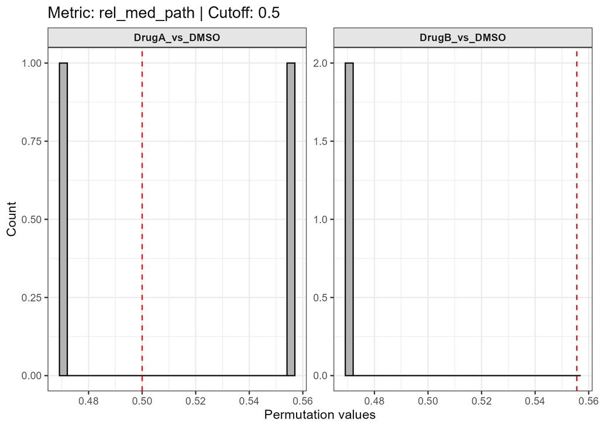

## Output: one folder per grid combination

`respath` above is just a base directory. Each distinct `(spec_cutoff, perc_cutoff, b, w, rank_uka_abs, ppi_network)` combination gets its **own** folder, same as plain generation with `networkGen`: the kinase example above grids 2 `perc_cutoff` values x 2 `b` values, so 4 folders, each with `results.csv`/`metrics_permutations.csv`/`metrics_observed.csv`, the faceted diagnostic histograms (`Network_metrics_plots/<metric>_cutoff<cutoff>.png` – permutation-null- distribution per metric, faceted by condition, observed value marked with a line), and each condition’s **observed** network (`nodes`/`edges`/`wc_df` CSVs). Permutation networks (there are `nperms_network` of them per condition) are never written – only the observed build:

```r
kinase_files <- list.files(respath_kinase, recursive = TRUE)
length(kinase_files)
```

```
#> [1] 60
```

```r
head(kinase_files, n = 2)
```

```
#> [1] "spec1_perc0.5_ppi_networkv12_502_kins_ukaabs1_b50_w10_nperms2/edges_DrugA_vs_DMSO_spec1.csv"
#> [2] "spec1_perc0.5_ppi_networkv12_502_kins_ukaabs1_b50_w10_nperms2/edges_DrugB_vs_DMSO_spec1.csv"
```

For the paired (golden) path, the folder additionally nests under a `uka`-named subfolder (since output there depends on both `uka` and `sens`):

```r
full_files <- list.files(respath_full, recursive = TRUE)
length(full_files)
```

```
#> [1] 24
```

```r
head(full_files, n = 2)
```

```
#> [1] "uka/sens_spec1_perc0.5_ppi_networkv12_502_kins_ukaabs1_b50_w10_nperms2/edges_DrugA_spec1.csv"
#> [2] "uka/sens_spec1_perc0.5_ppi_networkv12_502_kins_ukaabs1_b50_w10_nperms2/log_time.txt"
```

## Comparing scores across separate runs

`plot_score_comparison()` reads the `results.csv` under each of several result folders and plots `score_sig_network`/`score_sig_network_inv` as bars per `Comparison`, one facet per folder – for comparing the *same* comparisons across *different* parameter combinations, or entirely separate runs, one folder per combination (matching how output is laid out throughout this package – see “Output: one folder per grid combination” above). Give each folder an alias; that alias becomes its facet title, and facets appear in the order given, not alphabetically.

Two single-combination runs, differing only in `b`, to compare against each other (`respath_kinase` above isn’t a fit here – it’s the *base* folder for a whole grid of 4 combinations, not one combination itself):

```r
respath_b50 <- tempfile("kinase_score_b50_")
dir.create(respath_b50)
result_b50 <- make_golden_score(
  uka = toy_uka, spec_cutoff = 1.0, perc_cutoff = 0.6,
  ppi_network = ppi_networkv12_502_kins, b = 50, w = 10,
  respath = respath_b50, nperms_network = 2, n = 2
)
```

```
#> Running kinase-only golden score analysis...
#> Grid has 2 condition x spec_cutoff x perc_cutoff x b x w x rank_uka_abs x ppi_network cells
#> [1] "param folder: C:\\Users\\DSCHUL~1\\AppData\\Local\\Temp\\Rtmp4Mpf1E\\kinase_score_b50_46503dfd1c18/spec1_perc0.6_ppi_networkv12_502_kins_ukaabs1_b50_w10_nperms2"
#> # A tibble: 8 × 2
#>   parameter      value
#>   <chr>          <chr>
#> 1 spec_cutoff    1
#> 2 perc_cutoff    0.6
#> 3 b              50
#> 4 w              10
#> 5 rank_uka_abs   TRUE
#> 6 ppi_network    ppi_networkv12_502_kins
#> 7 uka            uka
#> 8 nperms_network 2
#> [1] "Building PCSF network..."
#>   100% of your terminal nodes are included in the interactome
#>   Solving the PCSF by adding random noise to the edge costs...
#> Run 1 of 2
#> Run 2 of 2
#> [1] "Building PCSF network..."
#>   100% of your terminal nodes are included in the interactome
#>   Solving the PCSF by adding random noise to the edge costs...
#> Run 1 of 2
#> Run 2 of 2
#> [1] "Building PCSF network..."
#>   100% of your terminal nodes are included in the interactome
#>   Solving the PCSF by adding random noise to the edge costs...
#> Run 1 of 2
#> Run 2 of 2
#> [1] "Building PCSF network..."
#>   100% of your terminal nodes are included in the interactome
#>   Solving the PCSF by adding random noise to the edge costs...
#> Run 1 of 2
#> Run 2 of 2
#> [1] "Building PCSF network..."
#>   100% of your terminal nodes are included in the interactome
#>   Solving the PCSF by adding random noise to the edge costs...
#> Run 1 of 2
#> Run 2 of 2
#> [1] "Building PCSF network..."
#>   100% of your terminal nodes are included in the interactome
#>   Solving the PCSF by adding random noise to the edge costs...
#> Run 1 of 2
#> Run 2 of 2
#> [1] "Run time: 3.91938900947571"
```

```r
respath_b75 <- tempfile("kinase_score_b75_")
dir.create(respath_b75)
result_b75 <- make_golden_score(
  uka = toy_uka, spec_cutoff = 1.0, perc_cutoff = 0.6,
  ppi_network = ppi_networkv12_502_kins, b = 75, w = 10,
  respath = respath_b75, nperms_network = 2, n = 2
)
```

```
#> Running kinase-only golden score analysis...
#> Grid has 2 condition x spec_cutoff x perc_cutoff x b x w x rank_uka_abs x ppi_network cells
#> [1] "param folder: C:\\Users\\DSCHUL~1\\AppData\\Local\\Temp\\Rtmp4Mpf1E\\kinase_score_b75_46501a717819/spec1_perc0.6_ppi_networkv12_502_kins_ukaabs1_b75_w10_nperms2"
#> # A tibble: 8 × 2
#>   parameter      value
#>   <chr>          <chr>
#> 1 spec_cutoff    1
#> 2 perc_cutoff    0.6
#> 3 b              75
#> 4 w              10
#> 5 rank_uka_abs   TRUE
#> 6 ppi_network    ppi_networkv12_502_kins
#> 7 uka            uka
#> 8 nperms_network 2
#> [1] "Building PCSF network..."
#>   100% of your terminal nodes are included in the interactome
#>   Solving the PCSF by adding random noise to the edge costs...
#> Run 1 of 2
#> Run 2 of 2
#> [1] "Building PCSF network..."
#>   100% of your terminal nodes are included in the interactome
#>   Solving the PCSF by adding random noise to the edge costs...
#> Run 1 of 2
#> Run 2 of 2
#> [1] "Building PCSF network..."
#>   100% of your terminal nodes are included in the interactome
#>   Solving the PCSF by adding random noise to the edge costs...
#> Run 1 of 2
#> Run 2 of 2
#> [1] "Building PCSF network..."
#>   100% of your terminal nodes are included in the interactome
#>   Solving the PCSF by adding random noise to the edge costs...
#> Run 1 of 2
#> Run 2 of 2
#> [1] "Building PCSF network..."
#>   100% of your terminal nodes are included in the interactome
#>   Solving the PCSF by adding random noise to the edge costs...
#> Run 1 of 2
#> Run 2 of 2
#> [1] "Building PCSF network..."
#>   100% of your terminal nodes are included in the interactome
#>   Solving the PCSF by adding random noise to the edge costs...
#> Run 1 of 2
#> Run 2 of 2
#> [1] "Run time: 3.14249992370605"
```

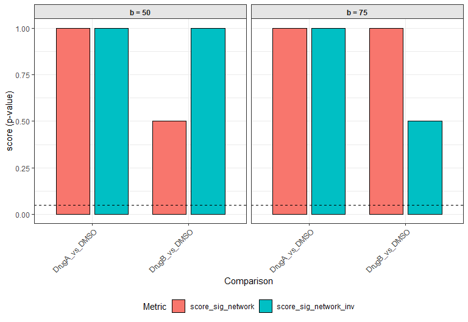

```r
plot_score_comparison(c("b = 50" = respath_b50, "b = 75" = respath_b75))
```

Only `Comparison` values present in **every** listed folder are kept – if you accidentally compare folders from unrelated runs with no comparisons in common, this refuses with a clear error instead of silently producing a misleading empty plot.

## Safety guard for large grids

Like `networkGen::run_network_grid()`, both functions refuse to proceed (without building anything) if the grid – with permutations included – would exceed `max_tasks` (default 500) networks:

```r
make_golden_score_kinase(
  uka = toy_uka, spec_cutoff = 1.0, perc_cutoff = c(0.5, 0.7),
  ppi_network = ppi_networkv12_502_kins, b = 50, respath = respath_kinase,
  nperms_network = 50, max_tasks = 10
)
```

```
#> Grid has 4 condition x spec_cutoff x perc_cutoff x b x w x rank_uka_abs x ppi_network cells
#> Error:
#> ! make_golden_score_kinase() would build 204 networks (4 grid cells x (1 observed + 50 permutations)), over max_tasks = 10. Review the grid before proceeding, or pass a higher max_tasks explicitly if this size is actually intended.
```

## Parallel vs. sequential execution

Every network needed – one observed plus `nperms_network` permuted, for every condition x `spec_cutoff` x `perc_cutoff` x `b` x `w` x `rank_uka_abs` x `ppi_network` combination – is submitted together, so a `future` plan set before calling parallelizes across all of it (every condition and every permutation at once, not just across conditions):

```r
future::plan(future::multisession, workers = 4)
```

Without a plan set, both functions run sequentially – still correct, just not parallel.